# Haplotype analysis *Rdl*

### Allele counts

Using both dictionaries:

```python
print("Genotypes phased to allele counts (population)...")
oc_hapalco_pop = oc_haploty.count_alleles_subpops(subpops=oc_popdict)
print(oc_hapalco_pop.shape)

print("Haplotypes phased to allele counts (population)...")
oc_hapalco_hap_pop = oc_haploty_hap.count_alleles_subpops(subpops=oc_popdich)
print(oc_hapalco_hap_pop.shape)
```

```
Genotypes phased to allele counts (population)...
(11332701,)
Haplotypes phased to allele counts (population)...
(11332701,)
```

### Filters

#### Retain segregating and non-singletons

Define which phased variants to retain from phase1 (all other datasets will be recast to fit this):

```python
# subset data: segregating alleles, biallelic and no singletons
print("Filters phased...")
oc_is_seg_h    = oc_hapalco_hap_pop["all"].is_segregating()[:] # segregating
oc_is_nosing_h = oc_hapalco_hap_pop["all"][:,:2].min(axis=1)>2 # no singletons

# subset phase2 to seg, nosing, biallelic & outgroup size
oc_hapvars_seg         = oc_hapvars.compress((oc_is_seg_h & oc_is_nosing_h))
oc_haploty_seg         = oc_haploty.compress((oc_is_seg_h & oc_is_nosing_h))
oc_hapalco_pop_seg     = oc_hapalco_pop.compress((oc_is_seg_h & oc_is_nosing_h))
oc_haploty_hap_seg     = oc_haploty_hap.compress((oc_is_seg_h & oc_is_nosing_h))
oc_hapalco_hap_pop_seg = oc_hapalco_hap_pop.compress((oc_is_seg_h & oc_is_nosing_h))

# report
print(oc_haploty_seg.shape,"/", oc_haploty.shape)
```

```
Filters phased...
(2126957, 103, 2) / (11332701, 103, 2)
```

Same for variant effects:

```python
oc_effvars_seg_pos = oc_effvars["POS"][:][is_eff_in_phased].compress((oc_is_seg_h & oc_is_nosing_h))
oc_effvars_seg_ref = oc_effvars["REF"][:][is_eff_in_phased].compress((oc_is_seg_h & oc_is_nosing_h))
oc_effvars_seg_alt = oc_effvars["ALT"][:][is_eff_in_phased].compress((oc_is_seg_h & oc_is_nosing_h))
oc_effvars_seg_gen = oc_effvars["ANN_Feature_ID"][:][is_eff_in_phased].compress((oc_is_seg_h & oc_is_nosing_h))
oc_effvars_seg_pep = oc_effvars["ANN_HGVS_p"][:][is_eff_in_phased].compress((oc_is_seg_h & oc_is_nosing_h))
oc_effvars_seg_cds = oc_effvars["ANN_HGVS_c"][:][is_eff_in_phased].compress((oc_is_seg_h & oc_is_nosing_h))
oc_effvars_seg_typ = oc_effvars["ANN_Annotation"][:][is_eff_in_phased].compress((oc_is_seg_h & oc_is_nosing_h))
oc_effvars_seg_pep.shape
```

```
(2126957,)
```

Create array of printable variant names:

```python
oc_snpname_seg = np.array(
    [chrom+":"+x1+" "+x2+" "+x3 for x1,x2,x3 in zip(
        oc_effvars_seg_pos.astype(str),
        oc_effvars_seg_gen.astype(str),
        oc_effvars_seg_pep.astype(str),
    )]
)
```

#### Retain min frequency and location

Is variant above certain minimum frequency?

```python
# allele counts table per pop
co_major = pd.DataFrame()
co_minor = pd.DataFrame()
fq_minor = pd.DataFrame()
for popi in oc_popl:
    co_major[popi] = oc_hapalco_pop_seg[popi][:,0]
    co_minor[popi] = oc_hapalco_pop_seg[popi][:,1]
    fq_minor[popi] = oc_hapalco_pop_seg[popi][:,1] / oc_hapalco_pop_seg[popi][:,0:2].sum(axis=1)
co_major["all"] = co_major.sum(axis=1)
co_minor["all"] = co_minor.sum(axis=1)
fq_minor["all"] = co_minor.sum(axis=1) / (co_minor.sum(axis=1)+co_major.sum(axis=1))

# subset data: keep variants with at least 5% freq in at least one pop
is_minfq  = np.logical_and(fq_minor.max(axis=1) > minfrq, fq_minor.min(axis=1) < 1-minfrq)
```

Is variant in the loci of interest? (useful for reporting)

```python
is_in_loci = np.logical_and(oc_hapvars_seg["POS"] >= loc_start, oc_hapvars_seg["POS"] <= loc_end)
```

Is variant non syn?

```python
is_nonsyn  = oc_effvars_seg_typ == "missense_variant"
```

Should variant frequency be reported? (in loci, nonsyn, min freq, segregating, non singleton):

```python
# report
is_report  = (is_in_loci & is_minfq & is_nonsyn)
print("in loci:                    ",sum(is_in_loci))
print("in loci, nonsyn and min frq:",sum(is_report))
```

```
in loci:                     582
in loci, nonsyn and min frq: 86
```

Print table with variants, effects and frequencies per population:

```python
# print table
fq_repor = pd.DataFrame(data={
    "chr"      : [chrom] * co_minor[is_in_loci].shape[0],
    "POS"      : oc_hapvars_seg["POS"].subset(sel0=is_in_loci)[:].astype(str),
    "REF"      : oc_hapvars_seg["REF"].subset(sel0=is_in_loci)[:].astype(str),
    "ALT"      : oc_hapvars_seg["ALT"].subset(sel0=is_in_loci)[:].astype(str),
    "is_nonsyn": is_nonsyn[is_in_loci],
    "gene_eff" : oc_effvars_seg_gen[is_in_loci].astype(str),
    "PEP_eff"  : oc_effvars_seg_pep[is_in_loci].astype(str),
    "CDS_eff"  : oc_effvars_seg_cds[is_in_loci].astype(str),
},
columns=["chr","POS","REF","ALT","gene_eff","PEP_eff","CDS_eff","is_nonsyn"]
)
fq_repor = pd.concat([fq_repor,fq_minor[is_in_loci].reset_index()],axis=1)
fq_repor.to_csv("%s/%s_%s.allele_fq.csv" % (outdir,outcode,l_nom),sep="\t",index=False)
```

Print table with genotypes of nonsyn variants, per sample:

```python
# dataframe with pops
gt_repor = pd.DataFrame(data={
    "ox_code"    : oc_samples["ox_code"],
    "population" : oc_samples["population"],
    "species"    : oc_samples["species"],
}
)

# retrieve 012 genotypes for report
gt_gtysa = pd.DataFrame(np.transpose(oc_haploty_seg.subset(sel0=is_report).to_n_alt(fill=-1)))
gt_gtysa.columns = oc_snpname_seg[is_report]

# print
gt_repor = pd.concat([gt_repor, gt_gtysa],axis=1)
gt_repor.to_csv("%s/%s_%s.allele_genotypes.csv" % (outdir,outcode,l_nom),sep="\t",index=False)
```

### Other data

Accessibility:

```python
# Accessibility
print("Load accessibility array...")
accessi_df  = h5py.File(oc_accessi_fn,mode="r")
accessi_arr = accessi_df[chrom]["is_accessible"][:]
```

```
Load accessibility array...
```

Gene annotations GFF:

```python
# import gff
def geneset_gff(geneset):
    items = []
    for n in geneset.dtype.names:
        v = geneset[n]
        if v.dtype.kind == 'S':
            v = v.astype('U')
        items.append((n, v))
    return pd.DataFrame.from_items(items)
%run scripts_printtranscripts/allel_printtranscripts_24gen18.py

geneset = allel.FeatureTable.from_gff3(gffann_fn,attributes=['ID', 'Parent'])
geneset = geneset_gff(geneset)
```

```python
geneset[geneset["Parent"] == "AGAP002867"]
```

|  | seqid | source | type | start | end | score | strand | phase | ID | Parent |
| --- | --- | --- | --- | --- | --- | --- | --- | --- | --- | --- |
| 69657 | 2R | VectorBase | mRNA | 28497087 | 28498674 | -1.0 | - | -1 | AGAP002867-RA | AGAP002867 |

## Variant frequency

First, plot frequency of coding variants inside of the gene itself:

```
Minor allele freqs...
```

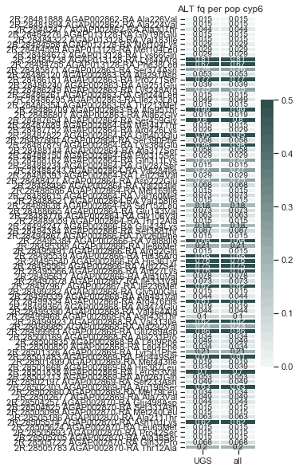

```python
print("Minor allele freqs...")

# plot minor allele freqs per pop
fig = plt.figure(figsize=(2,10))
pdf = PdfPages("%s/%s_%s.allele_fq.pdf" % (outdir,outcode,l_nom))

# plot
ax=sns.heatmap(fq_minor[is_report],vmin=0,vmax=0.5,cmap=sns.light_palette("darkslategray",n_colors=31),
               yticklabels=oc_snpname_seg[is_report],linewidths=0.8,linecolor="white",annot=True)
ax.set_title("ALT fq per pop %s" % l_nom)

pdf.savefig(fig,bbox_inches='tight')
pdf.close()
```

### Linkage disequilibrium

We calculate the **linkage disequilibrium** between all allele pairs, using two different metrics (Rogers & Huff $r$, Lewontin's $D'$).

Two functions for Lewontin $D'$:

```python
def lewontin_d_prime(h, i, j, a=1, b=1):
    h = allel.HaplotypeArray(h)
    n_a = n_b = 0  # allele counts
    n_ab = 0  # haplotype counts
    n = 0  # allele number (i.e., number of calls)
    for k in range(h.n_haplotypes): # iterate over haplotypes, counting alleles and haplotypes
        allele_ik = h[i, k]
        allele_jk = h[j, k]
        if allele_ik < 0 or allele_jk < 0:    continue
        if allele_ik == a:                    n_a += 1
        if allele_jk == b:                    n_b += 1
        if allele_ik == a and allele_jk == b: n_ab += 1
        n += 1
    if n == 0 or n_a == 0 or n_b == 0 or n == n_a or n == n_b:
        return None # bail out if no data or either allele is absent or fixed
    # compute coefficient of linkage disequilibrium * n**2
    D_ab = (n * n_ab) - (n_a * n_b)
    # compute normalisation coefficient * n**2
    if D_ab >= 0: D_max = min(n_a * (n - n_b), (n - n_a) * n_b)
    else:         D_max = min(n_a * n_b, (n - n_a) * (n - n_b))
    # compute D prime
    D_prime = D_ab / D_max
    return D_prime

def lewontin_d_prime_varloop(h):
    n = len(h)
    ld = np.zeros((n, n), dtype='f8')
    for i,_ in enumerate(h):
        for j,_ in enumerate(h):
            if i != j:
                ld[i, j] = lewontin_d_prime(h=h,i=i,j=j)
    return(ld)
```

LD calculations:

```python
# plot minor allele freqs per pop
pdf = PdfPages("%s/%s_%s.allele_ld.pdf" % (outdir,outcode,l_nom))

# linkage disequilibrium Rogers and Huff
print("LD Rogers & Huff...")
ld_rhr = allel.rogers_huff_r(oc_haploty_seg.compress(is_report).to_n_alt(fill=-1))
ld_rhr = squareform(ld_rhr)
np.fill_diagonal(ld_rhr,np.nan)
```

```
LD Rogers & Huff...
```

LD plot:

[figure not shown]

```python
fig = plt.figure(figsize=(10,8))
ax=sns.heatmap(ld_rhr,vmin=-1,vmax=1,cmap=sns.diverging_palette(20,255,s=99,sep=15,l=45,n=31),
               xticklabels=oc_snpname_seg[is_report],yticklabels=oc_snpname_seg[is_report],linewidths=0.2,linecolor="white",annot=True)
ax.set_title("Rogers & Huff $r$ %s" % l_nom)
pdf.savefig(fig,bbox_inches='tight')

# print table
ld_rhr_df = pd.DataFrame(ld_rhr)
ld_rhr_df.columns = oc_snpname_seg[is_report]
ld_rhr_df.rows    = oc_snpname_seg[is_report]
ld_rhr_df.to_csv("%s/%s_%s.allele_ld_rhr.csv" % (outdir,outcode,l_nom),sep="\t",index=False)
pdf.savefig(fig,bbox_inches='tight')
pdf.close()
```

## Haplotype networks

```python
# input hap networks
loc_vari = loc_p4 # variable to use as focus of hap networks -> position in the genome
loc_varn = "centre"   # name it

# parameters hap networks
fbp_hap  = 2e4     # num bp to retain around variant of interest (allele) to define core haplotyes, CC uses 6kbp
max_dist = 5       # dist that breaks edges; default is 5; CC uses 2 -> if network method is MJN, then it doesn't work for max_dist>1!!!!
max_alle = 1       # indirect variant breaks
net_meth = "msn"   # can be: minimum_spanning_network msn ; minimum_spanning_tree mst ; median_joining_network mjt
min_fq_h = 0.05    # min freq of the haplotype cluster, below that the component will be excluded from plots
min_fc_h = int(min_fq_h*oc_haploty_hap_seg.shape[1])

loc_vari_bool = np.any(oc_hapvars["POS"]   == loc_vari)
loc_vari_ix   = np.where(oc_hapvars["POS"] == loc_vari)[0][0]

# report
print("Is %i %s in phased array? %s: index %i " % (loc_vari,loc_varn,loc_vari_bool,loc_vari_ix))
```

```
Is 28497967 centre in phased array? True: index 6809110
```

Subset haplotypes to focus on variants around focal locus:

```python
# subset hap arrays to fit loci of interest (loci centre +/- fbp_hap)
loc_pos_ix = allel.SortedIndex(oc_hapvars_seg['POS'])
loc_pos_rn = loc_pos_ix.locate_range(loc_vari-fbp_hap,loc_vari+fbp_hap)

# snp name
oc_snpname_seg_mis = oc_snpname_seg
loc_hap    = oc_haploty_hap_seg[loc_pos_rn]
loc_snpnom = oc_effvars_seg_pep[loc_pos_rn]

# report
print("Phased variants and samples around %s:" % loc_vari,loc_hap.shape)

# color arrays
loc_colpos = np.array([pos_colors[p] for p in oc_sampleh["population"].values])
loc_gty_A  = oc_haploty_hap_seg[ np.where(loc_pos_ix==loc_vari)[0][0] ]       # genotype of A296G
loc_gty_T  = loc_gty_A
loc_colvar = np.array([var_colors[p] for p in loc_gty_T])
```

```
Phased variants and samples around 28497967: (949, 206)
```

Build **hap networks colored by population**, and store which samples are in which component:

```python
loc_graph, loc_distinct_sets, loc_components = graph_haplotype_network(
    h=loc_hap,
    max_dist=max_dist,
    max_allele=max_alle, # for MJN only; default is 3
    show_node_labels=min_fc_h,
    distance_metric='hamming',network_method=net_meth,
    hap_colors=loc_colpos,variant_labels=loc_snpnom,
    return_components=True,show_singletons=False)

num_components = loc_components.shape[0]

# plot pdf
loc_graph.format = 'pdf'
loc_graph.attr(label='\n\n%s %s %s:%i\n%i haps clustered into %i clusters with %s maxdist %i, from %i phased vars located +/- %i bp' % (l_nom,loc_varn,chrom,loc_vari,loc_hap.shape[1],num_components,net_meth,max_dist,loc_hap.shape[0],fbp_hap))
fn = "%s/%s_%s.hn_%s_var_%s_%s-pop" % (outdir,outcode,l_nom,net_meth,loc_vari,loc_varn)
loc_graph.render(fn,cleanup=True)
```

```
'haplotype_analysis_output/cyp6_UGS_cyp6.hn_msn_var_28497967_centre-pop.pdf'
```

```python
# map hap clusters with REF alleles to actual lists of populations
# BEWARE: identify_components fails if max_dist > 1 in MJN
def identify_components(h_distinct_sets, components):
    """This function is designed to collect all indices for original haplotypes
    within each connected component. I.e., it finds clusters from the network."""
    clusters = []
    for c in np.unique(components):
        cluster = set()
        for i in np.nonzero(components == c)[0]:
            cluster |= h_distinct_sets[i]
        clusters.append(sorted(cluster))
    return clusters

loc_components_id      = identify_components(loc_distinct_sets, loc_components)
loc_components_id_hapi = []
loc_components_id_clui = []
loc_components_id_dati = pd.DataFrame()
for n,i in enumerate(loc_components_id):
    loc_components_id_hapi = loc_components_id_hapi + loc_components_id[n]
    loc_components_id_clui = loc_components_id_clui + list([n]*len(loc_components_id[n]))

loc_components_id_dati["hap_index"]   = loc_components_id_hapi
loc_components_id_dati["hap_cluster"] = loc_components_id_clui
loc_components_id_dati                = loc_components_id_dati.sort_values(by="hap_index")
loc_components_id_dati                = loc_components_id_dati.set_index(keys="hap_index")
loc_components_id_dati["pop"]         = oc_sampleh["population"].values
loc_components_id_dati["hap_id"]      = oc_sampleh["ox_code"].values

# report
print("total haps:",loc_hap.shape[1])
print("num haps per cluster (only clusters n>=%i):" % min_fc_h)
print(loc_components_id_dati.groupby(("hap_cluster")).size()[loc_components_id_dati.groupby(("hap_cluster")).size()>=min_fc_h])
```

```
total haps: 206
num haps per cluster (only clusters n>=10):
hap_cluster
0    113
1     35
dtype: int64
```

```python
min_cluster_size = min_fc_h

# select clusters
clu_list_ids     = np.unique(loc_components_id_dati["hap_cluster"],return_counts=True)[0]
clu_list_cou     = np.unique(loc_components_id_dati["hap_cluster"],return_counts=True)[1]
clu_list_ids_fil = clu_list_ids[clu_list_cou >= min_cluster_size]
clu_list_cou_fil = clu_list_cou[clu_list_cou >= min_cluster_size]
loc_printhap     = np.isin(loc_components_id_dati["hap_cluster"].values, clu_list_ids_fil)

print(loc_varn,loc_vari,"print clusters:",clu_list_ids_fil,"\t\tsize of clusters: ",clu_list_cou_fil)
print(loc_varn,loc_vari,"print clusters total size:",sum(loc_printhap),"/",len(loc_printhap))
```

```
centre 28497967 print clusters: [0 1] 		size of clusters:  [113  35]
centre 28497967 print clusters total size: 148 / 206
```

```python
loc_graph, loc_distinct_sets, loc_components = graph_haplotype_network(
    h=loc_hap.subset(sel1=loc_printhap),
    max_dist=max_dist,
    max_allele=max_alle, # for MJN only; default is 3
    show_node_labels=100,
    distance_metric='hamming',network_method=net_meth,
    hap_colors=loc_colpos[loc_printhap],variant_labels=loc_snpnom,
    return_components=True,show_singletons=False)

num_components = loc_components.shape[0]

# plot pdf
loc_graph.format = 'pdf'
loc_graph.attr(label='\n\n%s %s %s:%i\n%i haps clustered into %i clusters with %s maxdist %i, from %i phased vars located +/- %i bp' % (l_nom,loc_varn,chrom,loc_vari,loc_hap.shape[1],num_components,net_meth,max_dist,loc_hap.shape[0],fbp_hap))
fn = "%s/%s_%s.hn_%s_var_%s_%s-pop_minfq" % (outdir,outcode,l_nom,net_meth,loc_vari,loc_varn)
loc_graph.render(fn,cleanup=True)
```

```
'haplotype_analysis_output/cyp6_UGS_cyp6.hn_msn_var_28497967_centre-pop_minfq.pdf'
```

- wt is gray (0)
- P4 is light blue (1)
- missing genotype is orange (-1)

```python
loc_components_id_dati["CYP6P4_nonsyn"] = loc_gty_T
```

```python
loc_graph, loc_distinct_sets, loc_components = graph_haplotype_network(
    h=loc_hap.subset(sel1=loc_printhap),
    max_dist=max_dist,
    max_allele=max_alle, # for MJN only; default is 3
    show_node_labels=100,
    distance_metric='hamming',network_method=net_meth,
    hap_colors=loc_colvar[loc_printhap],variant_labels=loc_snpnom,
    return_components=True,show_singletons=False)

num_components = loc_components.shape[0]

# plot pdf
loc_graph.format = 'pdf'
loc_graph.attr(label='\n\n%s %s %s:%i\n%i haps clustered into %i clusters with %s maxdist %i, from %i phased vars located +/- %i bp' % (l_nom,loc_varn,chrom,loc_vari,loc_hap.shape[1],num_components,net_meth,max_dist,loc_hap.shape[0],fbp_hap))
fn = "%s/%s_%s.hn_%s_var_%s_%s-gty_minfq" % (outdir,outcode,l_nom,net_meth,loc_vari,loc_varn)
loc_graph.render(fn,cleanup=True)
```

```
'haplotype_analysis_output/cyp6_UGS_cyp6.hn_msn_var_28497967_centre-gty_minfq.pdf'
```

```python
# plot color legend
# WARNING: colors might be slightly different because matplotlib and graphviz parse them differently
pdf = PdfPages("%s/%s_%s.hn_legend.pdf" % (outdir,outcode,l_nom))
fig,ax = plt.subplots(figsize=(1,1))
ax.set_axis_off()
custom_lines = [mpatches.Patch(facecolor=pos_colors[coli]) for coli in pos_colors.keys()]
plt.legend(labels=pos_colors.keys(),handles=custom_lines)
pdf.savefig(fig,bbox_inches='tight')
pdf.close()
```

Now, output table with clusters, for posterity:

```python
loc_components_id_dati.to_csv("%s/%s_%s.hn_result.csv" % (outdir,outcode,l_nom),sep="\t",index=False)
```

### Distribution of populations per haplotype

Barplots:

```python
def annotate_barplot(ax,color="k", labformat = "{:.2f}"):
    rects = ax.patches
    for rect in rects:
        x_value = rect.get_width()
        y_value = rect.get_y() + rect.get_height() / 2
        space   = 5
        ha      = 'left'
        label   = labformat.format(x_value) ## annotates bars with height labels, with 2 decimal points
        plt.annotate(label, (x_value, y_value), xytext=(space, 0), textcoords="offset points", va='center', ha=ha, color=color)
```

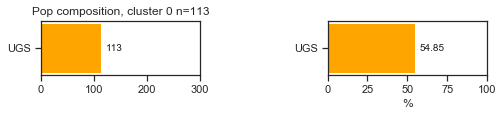

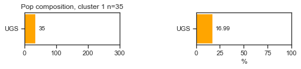

```python
pdf = PdfPages("%s/%s_%s.hn_popcomp_perhap.pdf" % (outdir,outcode,l_nom))

for i,clui in enumerate(clu_list_ids_fil):

    fig = plt.figure(figsize=(8,1))
    plt.subplots_adjust(left=None, bottom=None, right=None, top=None, wspace=0.8, hspace=None)

    # and now: some barplots with pop composition of each cluster
    ax1 = plt.subplot(1, 2, 1)
    hap_labl = "Pop composition, cluster "+str(clui)+" n="+str(clu_list_cou_fil[i])
    hap_clui = loc_components_id_dati["hap_id"][loc_components_id_dati["hap_cluster"] == int(clui)]
    hap_popi = loc_components_id_dati["pop"][loc_components_id_dati["hap_cluster"] == int(clui)]
    pie_labels = ["UGS"]
    pie_counts = [len(np.where(hap_popi==popi)[0]) for popi in pie_labels]
    pie_colors = [pos_colors[popi] for popi in pie_labels]
    plt.barh(width=pie_counts[::-1],y=pie_labels[::-1],color=pie_colors[::-1])
    ax1.set_xlim(0,300)
    annotate_barplot(ax=ax1, labformat="{:.0f}")
    plt.title(hap_labl)

    # and next: some barplots with pop % of each cluster
    ax2 = plt.subplot(1, 2, 2)
    hap_labl = "% of haps from each pop in cluster"
    pie_coutot = oc_sampleh.groupby("population").size()
    pie_coutot = pie_coutot[pie_labels]
    pie_fracti = pie_counts / pie_coutot * 100
    plt.barh(width=pie_fracti[::-1],y=pie_labels[::-1],color=pie_colors[::-1])
    annotate_barplot(ax=ax2, labformat="{:.2f}")
    ax2.set_xlabel("%")
    ax2.set_xlim(0,100)

    pdf.savefig(fig,bbox_inches='tight')

pdf.close()
```

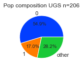

```python
pdf = PdfPages("%s/%s_%s.hn_popcomp_perpop.pdf" % (outdir,outcode,l_nom))

for popi in oc_popl:

    fig = plt.figure(figsize=(2,2))

    ax2 = plt.subplot(1, 1, 1)

    hap_popi = loc_components_id_dati["hap_cluster"][loc_components_id_dati["pop"] == popi]
    pie_coun = [sum(hap_popi == i) for i in clu_list_ids_fil]
    pie_coub = np.append(pie_coun, len(hap_popi)-sum(pie_coun))
    pie_labb = np.append(clu_list_ids_fil, "other")
    pie_titl = "Pop composition "+popi+" n="+str(len(hap_popi))
    ax2.pie(pie_coub,labels=pie_labb, autopct="%1.1f%%")
    plt.title(pie_titl)
    pdf.savefig(fig,bbox_inches='tight')

pdf.close()
```

## Selection signals in clusters

We want to see if the resistance haplotypes defined above have positive selection.

```python
min_cluster_size = 30

# select clusters
clu_list_ids     = np.unique(loc_components_id_dati["hap_cluster"],return_counts=True)[0]
clu_list_cou     = np.unique(loc_components_id_dati["hap_cluster"],return_counts=True)[1]
clu_list_ids_fil = clu_list_ids[clu_list_cou >= min_cluster_size]
clu_list_cou_fil = clu_list_cou[clu_list_cou >= min_cluster_size]

print(loc_varn,loc_vari,"print EHH for clusters:",clu_list_ids_fil,"\t\tsize of clusters: ",clu_list_cou_fil)
```

```
centre 28497967 print EHH for clusters: [0 1] 		size of clusters:  [113  35]
```

Create dictionary of associations haplotype-cluster:

```python
# create hap dictionary: similar to pop dict, but for associations hap-cluster
popdich_clu = dict()
# populate dict of interest
for clui in clu_list_ids_fil:
    clu_key = "cluster_"+str(clui)
    popdich_clu[clu_key] = [oc_sampleh["ox_code"].values.tolist().index(i) for i in loc_components_id_dati["hap_id"].values[loc_components_id_dati["hap_cluster"]==clui]]
# populate dict with all other samples
popdich_clu["cluster_no"] = []
for clui in clu_list_ids[clu_list_cou < min_cluster_size]:
    popdich_clu["cluster_no"] = popdich_clu["cluster_no"] + [oc_sampleh["ox_code"].values.tolist().index(i) for i in loc_components_id_dati["hap_id"].values[loc_components_id_dati["hap_cluster"]==clui]]

oc_hapalco_hap_clu_seg = oc_haploty_hap_seg.count_alleles_subpops(subpops=popdich_clu)
oc_hapalco_hap_clu_seg.shape
```

```
(2126957,)
```

### EHH decay

Now calculate **EHH decay** on the region of interest, using phased variants around it (+/- a certain number of bases):

```
EHH cluster_0
EHH cluster_1
EHH cluster_no
```

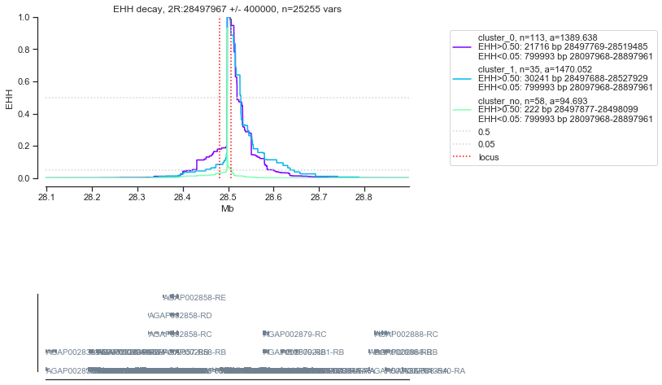

```python
colors        = cm.rainbow(np.linspace(0, 1, len(clu_list_ids_fil)+3))
ehh_above_thr = 0.50
ehh_below_thr = 0.05
flank_bp_EHH  = 400000

# variants to retain
clu_varbool_up = np.logical_and(oc_hapvars_seg["POS"] >= loc_vari-flank_bp_EHH, oc_hapvars_seg["POS"] < loc_vari)
clu_varbool_do = np.logical_and(oc_hapvars_seg["POS"] > loc_vari, oc_hapvars_seg["POS"] <= loc_vari+flank_bp_EHH)
clu_varbool    = np.logical_or(clu_varbool_up,clu_varbool_do)

# samples to remove from analysis (EHH function can't handle missing -1 data)
rmv_miss_ix   = np.unique(np.where(oc_haploty_hap_seg.subset(sel0=clu_varbool) == -1)[1]).tolist()
rmv_miss_bool = np.invert(np.isin(range(0,oc_haploty_hap_seg.n_haplotypes),test_elements=rmv_miss_ix))

# positions
clu_ehh_pos = oc_hapvars_seg["POS"].subset(sel0=clu_varbool)

# plot
pdf = PdfPages("%s/%s_%s.sel_EHHdecay.pdf" % (outdir,outcode,l_nom))
fig = plt.figure(figsize=(8,8))
ax3 = plt.subplot(2, 1, 1)

for i,clui in enumerate(np.append(clu_list_ids_fil,"no")):

    clu_key = "cluster_"+str(clui)
    print("EHH %s" % clu_key)

    # which variants include in the cluster-wise analysis of selection?
    clu_sambool = np.isin(range(0,oc_haploty_hap_seg.n_haplotypes),test_elements=popdich_clu[clu_key])
    clu_sambool = np.logical_and(clu_sambool,rmv_miss_bool)

    # calculate actual EHH
    clu_ehh_up_i = allel.ehh_decay(h=oc_haploty_hap_seg.subset(sel0=clu_varbool_up,sel1=clu_sambool))
    clu_ehh_do_i = allel.ehh_decay(h=oc_haploty_hap_seg.subset(sel0=clu_varbool_do,sel1=clu_sambool))
    clu_ehh_i    = np.concatenate((clu_ehh_up_i[::-1],clu_ehh_do_i))
    clu_ehh_i_ar = np.trapz(clu_ehh_i)
    ehh_above_start = clu_ehh_pos.compress(clu_ehh_i > ehh_above_thr)[0]
    ehh_above_end   = clu_ehh_pos.compress(clu_ehh_i > ehh_above_thr)[-1]
    ehh_below_start = clu_ehh_pos.compress(clu_ehh_i < ehh_below_thr)[0]
    ehh_below_end   = clu_ehh_pos.compress(clu_ehh_i < ehh_below_thr)[-1]

    # lab is data
    clu_lab    = "%s, n=%i, a=%.3f\nEHH>%.2f: %i bp %i-%i\nEHH<%.2f: %i bp %i-%i" % (
        clu_key, len(popdich_clu[clu_key]),clu_ehh_i_ar,
        ehh_above_thr, ehh_above_end-ehh_above_start, ehh_above_start, ehh_above_end,
        ehh_below_thr, ehh_below_end-ehh_below_start, ehh_below_start, ehh_below_end
    )

    # plot EHH background & foreground
    ax3.plot(clu_ehh_pos/1e6,clu_ehh_i,color=colors[i],label=clu_lab,mfc='none')

sns.despine(ax=ax3,offset=10)
ax3.set_title("EHH decay, %s:%i +/- %i, n=%s vars" % (chrom,loc_vari,flank_bp_EHH,clu_ehh_pos.shape[0]))
ax3.set_xlabel("Mb")
ax3.set_ylabel("EHH")
ax3.set_xlim(clu_ehh_pos[0]/1e6,clu_ehh_pos[-1]/1e6)
ax3.set_ylim(0,1)
plt.axhline(ehh_above_thr, color='lightgray',linestyle=":",label=str(ehh_above_thr))
plt.axhline(ehh_below_thr, color='lightgray',linestyle=":",label=str(ehh_below_thr))
plt.axvline(loc_start/1e6, color='red',linestyle=":",label="locus")
plt.axvline(loc_end/1e6, color='red',linestyle=":",label="")
ax3.legend(loc='center left', bbox_to_anchor=(1.1, 0.5))

# plot transcripts
ax4 = plt.subplot(4, 1, 4)
sns.despine(ax=ax4,offset=10)
ax4.axes.get_xaxis().set_ticks([])
ax4.axes.get_xlabel() == ""
locus_genel = plot_transcripts(
    geneset=geneset,chrom=chrom,
    start=clu_ehh_pos[0],stop=clu_ehh_pos[-1],
    height=0.2,label_transcripts=True,ax=ax4,label_axis=False,
    color="slategray")

# save
pdf.savefig(fig,bbox_inches='tight')
pdf.close()
```

```python
def mean_se_ci_report(x, ci=0.95, ddof=1):
    s    = x[~np.isnan(x)]
    n    = len(s)
    av   = np.mean(s)
    se   = np.std(s)
    cili = (1 - ci) / 2.
    cilo = np.quantile(np.sort(s), q=cili)
    ciup = np.quantile(np.sort(s), q=(ci + cili))
    return av, se, cilo, ciup, n
```

```
cluster_0
h = 0.052623 +/- 0.002819 SE, 0.049582-0.053089 CI95, n=113
cluster_1
h = 0.166387 +/- 0.015469 SE, 0.115865-0.171123 CI95, n=35
cluster_no
h = 0.950393 +/- 0.002124 SE, 0.948622-0.954261 CI95, n=58
```

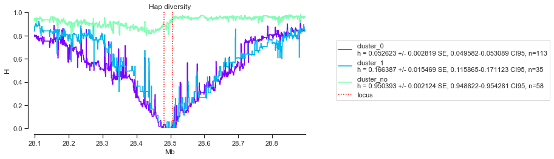

```python
colors        = cm.rainbow(np.linspace(0, 1, len(clu_list_ids_fil)+3))

# region to focus to calculate jack-knifed hap diversity
clu_varbool_focus = np.logical_and(oc_hapvars_seg["POS"] > loc_start, oc_hapvars_seg["POS"] <= loc_end)

pdf = PdfPages("%s/%s_%s.sel_hapdiv.pdf" % (outdir,outcode,l_nom))
fig = plt.figure(figsize=(8,12))
ax9 = plt.subplot(3, 1, 1)


j=0
for i,clui in enumerate(np.append(clu_list_ids_fil,"no")):

    # which cluster
    clu_key = "cluster_"+str(clui)

    # which variants include in the cluster-wise analysis of selection?
    clu_sambool = np.isin(range(0,oc_haploty_hap_seg.n_haplotypes),test_elements=popdich_clu[clu_key])
    clu_sambool = np.logical_and(clu_sambool,rmv_miss_bool)

    # hap div along chromosome
    clu_pos_wib    = allel.stats.moving_statistic(oc_hapvars_seg["POS"].subset(sel0=clu_varbool), statistic=lambda v: v[0], size=50, step=10)
    clu_hdi_wib    = allel.moving_haplotype_diversity(oc_haploty_hap_seg.subset(sel0=clu_varbool,sel1=clu_sambool), size=50, step=10)

    # hap div in focus region
    j_index = np.array(popdich_clu[clu_key]).tolist()
    j_run = len(j_index)
    j_hdi = np.zeros(shape=j_run)
    for k in range(j_run):
        j_sel1   = j_index[0:k] + j_index[k+1:j_run]
        j_hdi[k] = allel.haplotype_diversity(oc_haploty_hap_seg.subset(sel0=clu_varbool_focus, sel1=j_sel1))
    j_av,j_se,j_cl,j_cu,j_nu = mean_se_ci_report(j_hdi)
    clu_label = "%s\nh = %.6f +/- %.6f SE, %.6f-%.6f CI95, n=%i" % (clu_key, j_av, j_se, j_cl, j_cu, j_nu)
    print(clu_label)

    # plot
    plt.subplot(3, 1, 1)
    plt.step(clu_pos_wib/1e6, clu_hdi_wib, color=colors[j], label=clu_label)

    # next color
    j=j+1


sns.despine(ax=ax9,offset=10)
ax9.set_title("Hap diversity")
ax9.set_xlim(clu_ehh_pos[0]/1e6,clu_ehh_pos[-1]/1e6)
ax9.set_ylim(0,1)
ax9.set_xlabel("Mb")
ax9.set_ylabel("H")
plt.axvline(loc_start/1e6, color='red',linestyle=":",label="locus")
plt.axvline(loc_end/1e6, color='red',linestyle=":",label="")
ax9.legend(loc='center left', bbox_to_anchor=(1.1, 0.5))

# save
pdf.savefig(fig,bbox_inches='tight')
pdf.close()
```

### Garud H

Compute **Garud H** for each cluster, along the entire chromosome, to see landscape:

```
Retain...
Garud H cluster_0 - chr...
Hap div cluster_0 - chr...
Plots   cluster_0...
Garud H cluster_1 - chr...
Hap div cluster_1 - chr...
Plots   cluster_1...
Garud H cluster_no - chr...
Hap div cluster_no - chr...
Plots   cluster_no...
```

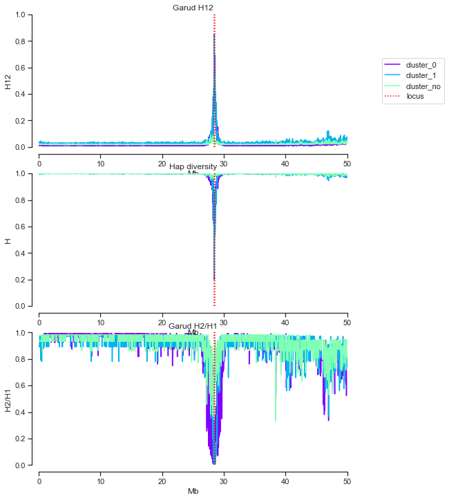

```python
# parameters
block_len_hap = 1000   # for the whole-genome view
step_len_hap  = 500    # for the whole-genome view
colors        = cm.rainbow(np.linspace(0, 1, len(clu_list_ids_fil)+3))
fbp_hap_extra = 1e6

# variants to retain
print("Retain...")
clu_pos_wib    = allel.stats.moving_statistic(oc_hapvars_seg["POS"], statistic=lambda v: v[0], size=block_len_hap,step=step_len_hap)

# open pdf
pdf = PdfPages("%s/%s_%s.sel_garudH.pdf" % (outdir,outcode,l_nom))
fig = plt.figure(figsize=(8,12))

# whole chromosome: frame
ax1 = plt.subplot(3, 1, 1)
sns.despine(ax=ax1,offset=10)
ax1.set_title("Garud H12")
ax1.set_xlim(ret_start/1e6,50)
ax1.set_ylim(0,1)
ax1.set_xlabel("Mb")
ax1.set_ylabel("H12")

ax2 = plt.subplot(3, 1, 3)
sns.despine(ax=ax2,offset=10)
ax2.set_title("Garud H2/H1")
ax2.set_xlim(ret_start/1e6,50)
ax2.set_ylim(0,1)
ax2.set_xlabel("Mb")
ax2.set_ylabel("H2/H1")

ax3 = plt.subplot(3, 1, 2)
sns.despine(ax=ax3,offset=10)
ax3.set_title("Hap diversity")
ax3.set_xlim(ret_start/1e6,50)
ax3.set_ylim(0,1)
ax3.set_xlabel("Mb")
ax3.set_ylabel("H")

for i,clui in enumerate(np.append(clu_list_ids_fil,"no")):

    # which variants include in the cluster-wise analysis of selection?
    clu_key     = "cluster_"+str(clui)
    clu_sambool = np.isin(range(0,oc_haploty_hap_seg.n_haplotypes),test_elements=popdich_clu[clu_key])

    # selection: Garud's H
    print("Garud H %s - chr..." % clu_key)
    clu_gah_wib = allel.moving_garud_h(oc_haploty_hap_seg.subset(sel1=popdich_clu[clu_key]), size=block_len_hap, step=step_len_hap)

    # haplotype diversity
    print("Hap div %s - chr..." % clu_key)
    clu_hdi_wib = allel.moving_haplotype_diversity(oc_haploty_hap_seg.subset(sel1=popdich_clu[clu_key]), size=block_len_hap, step=step_len_hap)

    print("Plots   %s..." % clu_key)
    # plot H12
    plt.subplot(3, 1, 1)
    plt.step(clu_pos_wib/1e6, clu_gah_wib[1], color=colors[i], label=clu_key)

    # plot H2H1
    plt.subplot(3, 1, 3)
    plt.step(clu_pos_wib/1e6, clu_gah_wib[3], color=colors[i])

    # plot hap div
    plt.subplot(3, 1, 2)
    plt.step(clu_pos_wib/1e6, clu_hdi_wib, color=colors[i])

plt.subplot(3, 1, 1)
plt.axvline(loc_start/1e6, color='red',linestyle=":",label="locus")
plt.axvline(loc_end/1e6, color='red',linestyle=":",label="")
ax1.legend(loc='center left', bbox_to_anchor=(1.1, 0.5))

plt.subplot(3, 1, 3)
plt.axvline(loc_start/1e6, color='red',linestyle=":",label="locus")
plt.axvline(loc_end/1e6, color='red',linestyle=":",label="")

plt.subplot(3, 1, 2)
plt.axvline(loc_start/1e6, color='red',linestyle=":",label="locus")
plt.axvline(loc_end/1e6, color='red',linestyle=":",label="")

pdf.savefig(fig,bbox_inches='tight')
pdf.close()
```

### Calculate selection statistics in the loci of interest

- **jack-knifing**: remove one sample (specimen) at a time without replacement and recalculate the statistic $n$ times ($n$=number of samples in each group, which will vary according to each haplotype cluster). This is the appropiate procedure for haplotype similarity statistics: a priori, the iterative removal of samples can both increase or decrease the statistic, which makes it a good measure of the robustness of the estimate.
- **bootstraping**: resample specimens with replacement, for $n=100$ iterations (where the number of samples in each iteration equals the number of samples in each group). This is **not adequate** for this particular statistic, because when you resample with replacement you're introducing duplicated samples that will always result in an upwards bias for statistics that measure haplotype similarity.

Selection statistics within core haplotype:

```python
clu_varbool    = np.logical_and(oc_hapvars_seg["POS"] >= loc_vari-fbp_hap , oc_hapvars_seg["POS"] <= loc_vari+fbp_hap)

for i,clui in enumerate(np.append(clu_list_ids_fil,"no")):

    # cluster key
    clu_key     = "cluster_"+str(clui)
    print("Locus: %i vars, cluster %s" % (sum(clu_varbool),clu_key))

    # haplotype diversity
    j_run = len(popdich_clu[clu_key])
    j_hdi = np.zeros(shape=j_run)
    for i in range(j_run):
        j_sel1   = popdich_clu[clu_key][0:i] + popdich_clu[clu_key][i+1:j_run]
        j_hdi[i] = allel.haplotype_diversity(oc_haploty_hap_seg.subset(sel0=clu_varbool, sel1=j_sel1))
    j_av,j_se,j_cl,j_cu,j_nu = mean_se_ci_report(j_hdi)
    print("Hap div %s \t = %.6f +/- %.6f SE, %.6f-%.6f CI95, n=%i" % (clu_key, j_av, j_se, j_cl, j_cu, j_nu))

    # Garud H12
    j_run  = len(popdich_clu[clu_key])
    j_h12  = np.zeros(shape=j_run)
    j_h2h1 = np.zeros(shape=j_run)
    for i in range(j_run):
        j_sel1    = popdich_clu[clu_key][0:i] + popdich_clu[clu_key][i+1:j_run]
        j_hstat   = allel.garud_h(oc_haploty_hap_seg.subset(sel0=clu_varbool, sel1=j_sel1))
        j_h12[i]  = j_hstat[1]
        j_h2h1[i] = j_hstat[3]
    j_av,j_se,j_cl,j_cu,j_nu = mean_se_ci_report(j_h12)
    print("H12 %s     \t = %.6f +/- %.6f SE, %.6f-%.6f CI95, n=%i" % (clu_key, j_av, j_se, j_cl, j_cu, j_nu))
    j_av,j_se,j_cl,j_cu,j_nu = mean_se_ci_report(j_h2h1)
    print("H2H1 %s    \t = %.6f +/- %.6f SE, %.6f-%.6f CI95, n=%i" % (clu_key, j_av, j_se, j_cl, j_cu, j_nu))
```

```
Locus: 949 vars, cluster cluster_0
Hap div cluster_0 	 = 0.385904 +/- 0.005512 SE, 0.374839-0.388835 CI95, n=113
H12 cluster_0     	 = 0.769147 +/- 0.005126 SE, 0.767219-0.782844 CI95, n=113
H2H1 cluster_0    	 = 0.017914 +/- 0.000899 SE, 0.015259-0.018288 CI95, n=113
Locus: 949 vars, cluster cluster_1
Hap div cluster_1 	 = 0.448739 +/- 0.018977 SE, 0.415330-0.459893 CI95, n=35
H12 cluster_1     	 = 0.691696 +/- 0.018257 SE, 0.683391-0.731834 CI95, n=35
H2H1 cluster_1    	 = 0.022138 +/- 0.002596 SE, 0.014577-0.023438 CI95, n=35
Locus: 949 vars, cluster cluster_no
Hap div cluster_no 	 = 0.987901 +/- 0.000670 SE, 0.987469-0.989348 CI95, n=58
H12 cluster_no     	 = 0.038940 +/- 0.001456 SE, 0.035396-0.039705 CI95, n=58
H2H1 cluster_no    	 = 0.832586 +/- 0.003862 SE, 0.824176-0.835052 CI95, n=58
```

A useful but unused function to calculate bootstraps:

```python
# boot_run = 100
# boot_rep = np.zeros(shape=boot_run)
# for i in range(boot_run):
#     boot_ran    = np.random.RandomState(None)
#     boot_sel1   = boot_ran.choice(popdich_clu[clu_key], size=len(popdich_clu[clu_key]), replace=True)
#     boot_rep[i] = allel.haplotype_diversity(oc_haploty_hap_seg.subset(sel0=clu_varbool, sel1=boot_sel1))
# print(mean_se_ci_report(boot_rep))
```

## Can we phase additional mutations?

If we find variants that are in high linkage disequilibrium with specimens that are 0 or 2 for the P4 mutation, we can use them to infer whether a particular haplotype has ZZB, dups, or indels.

First, load info of extra mutations:

```python
kary_df = pd.read_csv(kary_fn, sep='\t')
print("extra mutations:",kary_df.shape)
```

```
extra mutations: (103, 4)
```

```python
oc_haploty_seg_loci_extramut = np.vstack(
    (np.transpose(kary_df)[1:4],
     oc_haploty_seg.compress(is_in_loci).to_n_alt(fill=-1)[:])
)

print(oc_haploty_seg_loci_extramut.shape)

# calculate their LD
# linkage disequilibrium Rogers and Huff
print("LD Rogers & Huff...")
ld_rhr_extramut = allel.rogers_huff_r(oc_haploty_seg_loci_extramut)
ld_rhr_extramut = squareform(ld_rhr_extramut)
np.fill_diagonal(ld_rhr_extramut,np.nan)
```

```
(585, 103)
LD Rogers & Huff...
```

Are any of them in high linkage disequilibrium with the extra mutations?

```python
ld_threshold = 0.97 ## I choose this threshold so as to obtain just one variant.
is_ld_zzb    = ld_rhr_extramut[0] >= ld_threshold
is_ld_dup    = ld_rhr_extramut[1] >= ld_threshold
is_ld_indel  = ld_rhr_extramut[2] >= ld_threshold

# how many?
print("zzb",sum(is_ld_zzb))
print("dup",sum(is_ld_dup))
print("indel",sum(is_ld_indel))
```

```
zzb 2
dup 0
indel 2
```

Which ones? For ZZB:

```python
print(oc_snpname_seg[is_in_loci][is_ld_zzb[3:]])
print(ld_rhr_extramut[0][is_ld_zzb][1:])
```

```
['2R:28491424 AGAP002865-RA ']
[0.9749238]
```

For the indel:

```python
print(oc_snpname_seg[is_in_loci][is_ld_indel[3:]])
print(ld_rhr_extramut[2][is_ld_indel][1:])
```

```
['2R:28491424 AGAP002865-RA ']
[0.9749238]
```

So we conclude that we can use `2R:28491424` as the tagging variant for the ZZB insertion and for the small deletion (but there are no variants linked to the duplication).

Where is it?

```python
is_tagvar   = oc_hapvars_seg["POS"] == 28491424
loc_gty_tag = oc_haploty_hap_seg.subset(sel0=is_tagvar)
np.unique(is_tagvar, return_counts=True)
```

```
(array([False,  True]), array([2126956,       1]))
```

### Export FASTA

We create a haplotype-level table with key genotypes:

```python
kary_df_hap = pd.DataFrame(data={
    "ox_code" : list(itertools.chain(*[[ s + 'a', s + 'b'] for s in kary_df["ox_code"].values.tolist()])),
    "zzb"     : list(itertools.chain(*[[ s      , s      ] for s in kary_df["zzb"].values.tolist()])),
    "dupaa1"  : list(itertools.chain(*[[ s      , s      ] for s in kary_df["dupaa1"].values.tolist()])),
    "indel"   : list(itertools.chain(*[[ s      , s      ] for s in kary_df["indel"].values.tolist()])),
    "tagvar"  : loc_gty_tag[0].tolist(),
})

kary_df_hap.shape
```

```
(206, 5)
```

Retrieve genotype of P4 allele:

```python
oc_sampleh["P4_allele"] = loc_gty_T.astype(str)
```

Create alignment dataframe:

```python
happhy = pd.DataFrame({
    "hap": ">"+oc_sampleh["ox_code"]+"_"+oc_sampleh["population"]+"_gt"+oc_sampleh["P4_allele"]+
    "_zzb"+kary_df_hap["zzb"].astype(str)+"_dup"+kary_df_hap["dupaa1"].astype(str)+"_indel"+kary_df_hap["indel"].astype(str)+
    "_clu"+loc_components_id_dati["hap_cluster"].values.astype(str)+"_tag"+kary_df_hap["tagvar"].astype(str),
    "seq": np.nan},
    columns=["hap", "seq"])
happhy.head()
```

|  | hap | seq |
| --- | --- | --- |
| 0 | >AC0090-Ca_UGS_gt1_zzb2_dup0_indel2_clu0_tag1 | NaN |
| 1 | >AC0090-Cb_UGS_gt1_zzb2_dup0_indel2_clu0_tag1 | NaN |
| 2 | >AC0091-Ca_UGS_gt1_zzb2_dup0_indel2_clu0_tag1 | NaN |
| 3 | >AC0091-Cb_UGS_gt1_zzb2_dup0_indel2_clu0_tag1 | NaN |
| 4 | >AC0092-Ca_UGS_gt1_zzb2_dup2_indel2_clu0_tag1 | NaN |

FASTA cluster:

```python
export_name        = "loc"
loc_varbool        = np.logical_and(oc_hapvars_seg["POS"][:] >= loc_start, oc_hapvars_seg["POS"][:] <= loc_end)
fa_haploty_hap_seg = oc_haploty_hap_seg.compress(loc_varbool)
fa_hapvars_seg     = oc_hapvars_seg.compress(loc_varbool)
print(export_name,fa_haploty_hap_seg.shape, fa_hapvars_seg.shape)

for pn,popi in enumerate(oc_sampleh["ox_code"]):

    if pn % int(happhy.shape[0]/10) == 0 : print(pn,"/",happhy.shape[0])
    popi_gen = np.ndarray.tolist(fa_haploty_hap_seg[:,pn])
    popi_seq = [fa_hapvars_seg["REF"][gn].astype(str) if gei == 0 else fa_hapvars_seg["ALT"][gn].astype(str) for gn,gei in enumerate(popi_gen)]
    happhy["seq"][pn] = ''.join(str(e) for e in popi_seq)

print(pn,"/",happhy.shape[0])
happhy.to_csv("%s/%s_%s.alig_%s.fasta" % (outdir,outcode,l_nom,export_name),sep="\n",index=False, header=False)
pd.DataFrame({
    "POS" : oc_hapvars_seg["POS"].subset(loc_varbool)[:]
}).to_csv("%s/%s_%s.alig_%s.pos" % (outdir,outcode,l_nom,export_name),sep="\n",index=False, header=False)
```

```
loc (582, 206) (582,)
0 / 206
20 / 206
40 / 206
60 / 206
80 / 206
100 / 206
120 / 206
140 / 206
160 / 206
180 / 206
200 / 206
205 / 206
```

FASTA wider region:

```python
export_name        = "loc1e5"
loc_varbool        = np.logical_and(oc_hapvars_seg["POS"][:] >= loc_start-1e5, oc_hapvars_seg["POS"][:] <= loc_end+1e5)
fa_haploty_hap_seg = oc_haploty_hap_seg.compress(loc_varbool)
fa_hapvars_seg     = oc_hapvars_seg.compress(loc_varbool)
print(export_name,fa_haploty_hap_seg.shape, fa_hapvars_seg.shape)

for pn,popi in enumerate(oc_sampleh["ox_code"]):

    if pn % int(happhy.shape[0]/10) == 0 : print(pn,"/",happhy.shape[0])
    popi_gen = np.ndarray.tolist(fa_haploty_hap_seg[:,pn])
    popi_seq = [fa_hapvars_seg["REF"][gn].astype(str) if gei == 0 else fa_hapvars_seg["ALT"][gn].astype(str) for gn,gei in enumerate(popi_gen)]
    happhy["seq"][pn] = ''.join(str(e) for e in popi_seq)

print(pn,"/",happhy.shape[0])
happhy.to_csv("%s/%s_%s.alig_%s.fasta" % (outdir,outcode,l_nom,export_name),sep="\n",index=False, header=False)
pd.DataFrame({
    "POS" : oc_hapvars_seg["POS"].subset(loc_varbool)[:]
}).to_csv("%s/%s_%s.alig_%s.pos" % (outdir,outcode,l_nom,export_name),sep="\n",index=False, header=False)
```

```
loc1e5 (5837, 206) (5837,)
0 / 206
20 / 206
40 / 206
60 / 206
80 / 206
100 / 206
120 / 206
140 / 206
160 / 206
180 / 206
200 / 206
205 / 206
```